# Practical Machine Learning project

## Background

Using devices such as Jawbone Up, Nike FuelBand, and Fitbit it is now possible to collect a large amount of data about personal activity relatively inexpensively. These type of devices are part of the quantified self movement – a group of enthusiasts who take measurements about themselves regularly to improve their health, to find patterns in their behavior, or because they are tech geeks. One thing that people regularly do is quantify how much of a particular activity they do, but they rarely quantify how well they do it. In this project, your goal will be to use data from accelerometers on the belt, forearm, arm, and dumbell of 6 participants. They were asked to perform barbell lifts correctly and incorrectly in 5 different ways. More information is available from the website here: http://groupware.les.inf.puc-rio.br/har (see the section on the Weight Lifting Exercise Dataset).

### Data

The training data for this project are available here: https://d396qusza40orc.cloudfront.net/predmachlearn/pml-training.csv

The test data are available here: https://d396qusza40orc.cloudfront.net/predmachlearn/pml-testing.csv

The data for this project come from this source: http://groupware.les.inf.puc-rio.br/har.

```r
require(caret)
require(doMC)
```

```r
set.seed(100)
setwd("~/git/ML-Project")
url <- "https://d396qusza40orc.cloudfront.net/predmachlearn/pml-training.csv"
download.file(url, destfile="pml-training.csv", method = 'curl')
dataTrain <- read.csv("pml-training.csv")
```

The objective is to predict the classe variable

```r
str(dataTrain$classe)
```

```
##  Factor w/ 5 levels "A","B","C","D",..: 1 1 1 1 1 1 1 1 1 1 ...
```

```r
summary(dataTrain$classe)
```

```
##    A    B    C    D    E
## 5580 3797 3422 3216 3607
```

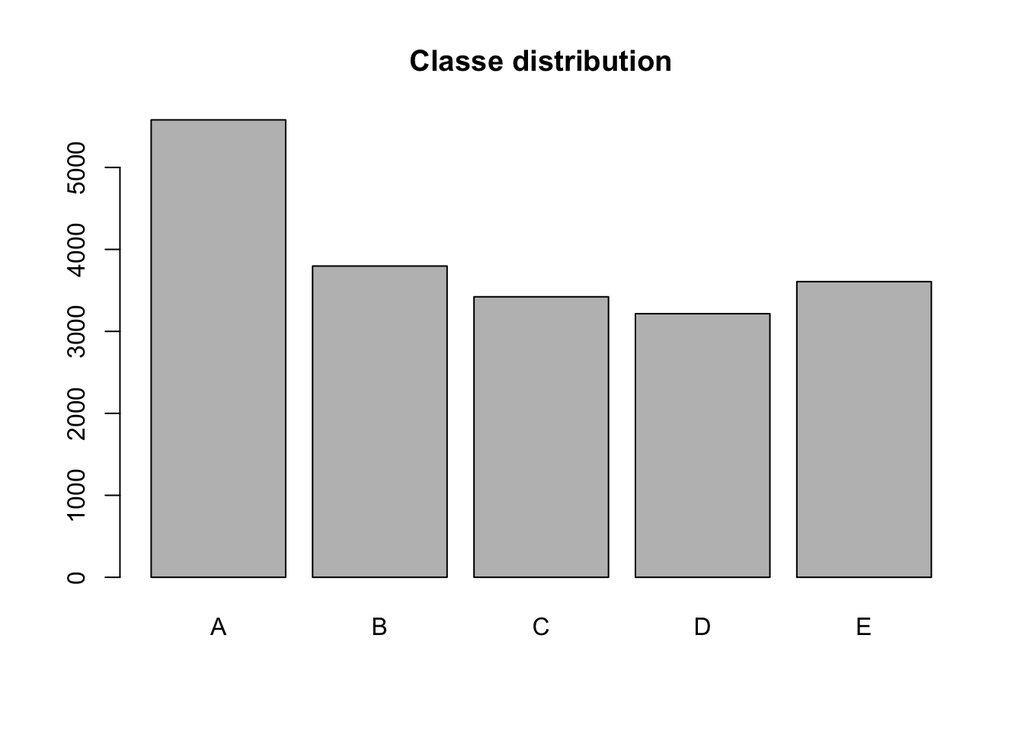

We will use variables with complete rows, and reduce the dataset. We will also remove Name, ID, and timestamp variables that may interfere and not help the model

```r
varIncomplete <- sapply(dataTrain, function (x) any(is.na(x) | x == ""))
dataTrainPrediction <- dataTrain[, !varIncomplete]
dataTrainPrediction <- dataTrainPrediction[, !grepl("X|user_name|.timestamp.|.timestamp|.window", names(dataTrainPrediction))]
```

```r
dim(dataTrainPrediction)
```

```
## [1] 19622    53
```

Next, we will partition and pre-process the training dataset

```r
# Partitioning
part <- createDataPartition(y=dataTrainPrediction$classe, p=0.6, list=FALSE)
dataTrainModel <- dataTrainPrediction[part, ]
dataProbeModel <- dataTrainPrediction[-part, ]
preProc <- preProcess(dataTrainModel)
preProc
```

```
## Created from 11776 samples and 53 variables
##
## Pre-processing:
##   - centered (52)
##   - ignored (1)
##   - scaled (52)
```

```r
dataTrainModelPC <- predict(preProc, dataTrainModel) # Apply to train set
preProc <- preProcess(dataProbeModel)
dataProbeModelPC <- predict(preProc, dataProbeModel) # Apply to Probe set
```

## Select a model and train

The dataset looks suitable for the RF (random forest) prediction model. The error threshold we will use to measure success is 3%. We will use the parallel processing to speed up learning.

```r
registerDoMC(cores = 4)
classeModel <- train(classe ~ ., data=dataTrainModelPC, method="parRF")
classeModel
```

```
## Parallel Random Forest
##
## 11776 samples
##    52 predictor
##     5 classes: 'A', 'B', 'C', 'D', 'E'
##
## No pre-processing
## Resampling: Bootstrapped (25 reps)
## Summary of sample sizes: 11776, 11776, 11776, 11776, 11776, 11776, ...
## Resampling results across tuning parameters:
##
##   mtry  Accuracy   Kappa      Accuracy SD  Kappa SD
##    2    0.9788262  0.9732833  0.034755316  0.043571013
##   27    0.9857546  0.9819746  0.002394804  0.003020022
##   52    0.9749978  0.9683617  0.004889419  0.006169036
##
## Accuracy was used to select the optimal model using  the largest value.
## The final value used for the model was mtry = 27.
```

We now try the model against the probing dataset

```r
predProbe <- predict(classeModel, dataProbeModelPC)
confusionMatrix(predProbe, dataProbeModelPC$classe)
```

```
## Confusion Matrix and Statistics
##
##           Reference
## Prediction    A    B    C    D    E
##          A 2229    6    1    1    0
##          B    3 1505   49    0    1
##          C    0    7 1314   38   13
##          D    0    0    4 1243   12
##          E    0    0    0    4 1416
##
## Overall Statistics
##
##                Accuracy : 0.9823
##                  95% CI : (0.9791, 0.9851)
##     No Information Rate : 0.2845
##     P-Value [Acc > NIR] : < 2.2e-16
##
##                   Kappa : 0.9776
##  Mcnemar's Test P-Value : NA
##
## Statistics by Class:
##
##                      Class: A Class: B Class: C Class: D Class: E
## Sensitivity            0.9987   0.9914   0.9605   0.9666   0.9820
## Specificity            0.9986   0.9916   0.9910   0.9976   0.9994
## Pos Pred Value         0.9964   0.9660   0.9577   0.9873   0.9972
## Neg Pred Value         0.9995   0.9979   0.9917   0.9935   0.9960
## Prevalence             0.2845   0.1935   0.1744   0.1639   0.1838
## Detection Rate         0.2841   0.1918   0.1675   0.1584   0.1805
## Detection Prevalence   0.2851   0.1986   0.1749   0.1605   0.1810
## Balanced Accuracy      0.9986   0.9915   0.9758   0.9821   0.9907
```

```r
classeModel$finalModel
```

[output not shown]

A plot of the final model:

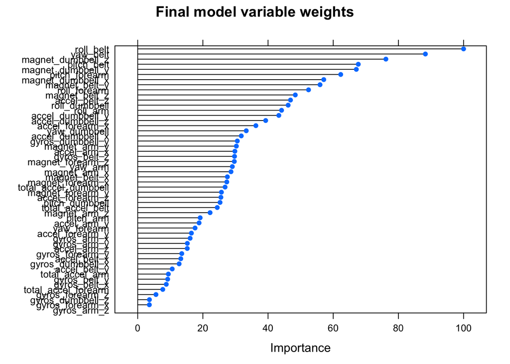

## Use the model to predict Testing set

We load and prepare the data

```r
load(file="classeModel.RData", verbose=TRUE) # re-loading the model
```

```
## Loading objects:
##   classeModel
```

```r
url2 <- "https://d396qusza40orc.cloudfront.net/predmachlearn/pml-testing.csv"
download.file(url2, destfile="pml-testing.csv", method = 'curl')
dataTest <- read.csv("pml-testing.csv")
#preProc <- preProcess(dataTest)
dataTestPC <- predict(preProc, dataTest) # Pre-process test dataset
```

Predict:

```r
pred_classe <- predict(classeModel, dataTestPC)
dataTestPC <- cbind(pred_classe, dataTestPC)
dataTestPC[, c("user_name","pred_classe")]
```

```
##    user_name pred_classe
## 1      pedro           B
## 2     jeremy           A
## 3     jeremy           B
## 4     adelmo           A
## 5     eurico           A
## 6     jeremy           E
## 7     jeremy           D
## 8     jeremy           B
## 9   carlitos           A
## 10   charles           A
## 11  carlitos           B
## 12    jeremy           C
## 13    eurico           B
## 14    jeremy           A
## 15    jeremy           E
## 16    eurico           E
## 17     pedro           A
## 18  carlitos           B
## 19     pedro           B
## 20    eurico           B
```

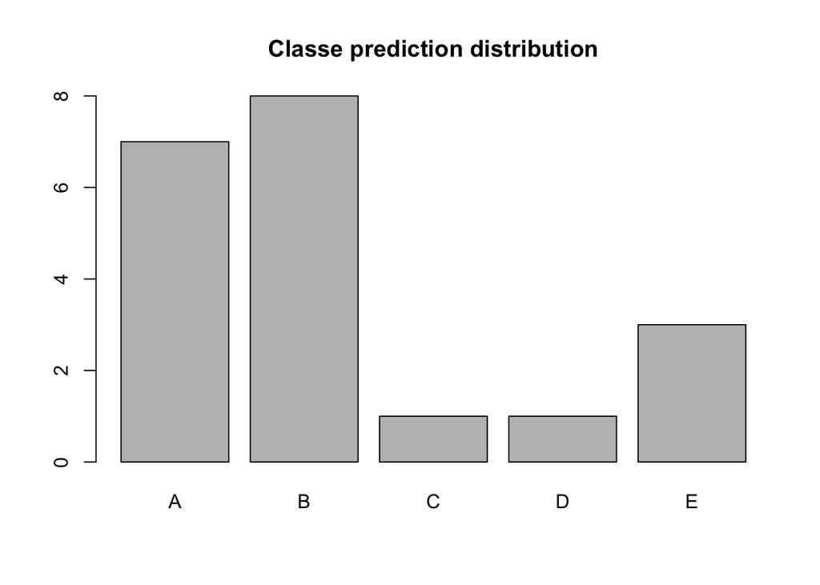